# 4. {ggplot2} (basic)

### Step 3: Select a graph

- You choose a geometric object, `geom_point()` to draw a scatter plot
- You can add `geom_point()` by using `+`

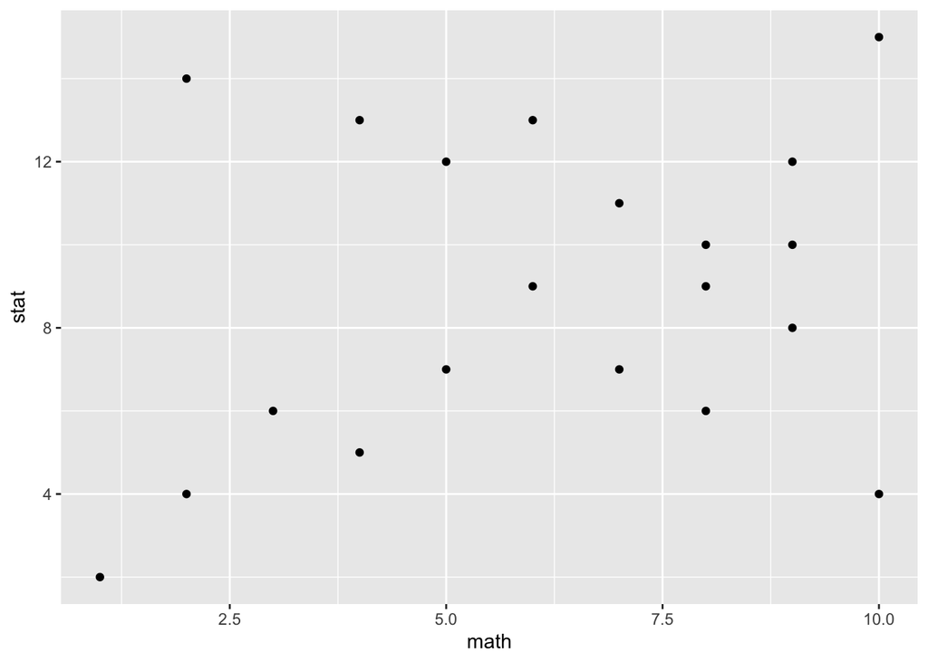

```r
ggplot(data = df1) +
  aes(x = math, y = stat) +
  geom_point()
```

- `aes(x = math, y = stat)` is an independent layer
- But, **you can put `aes(x = math, y = stat)` within `geom_point()`**
- This means that you map `aes()` within `geom_point()`
- Within `geom_point()`, you need to map by tying `mapping =`
- Within `aes()`, you need to link each element (such as a dot, line, or surface) to a particular variable  
  → Here, we link `x axis` is linked to `math`, `y axis` is linked to `stat`, and each dots are colored by `gender`

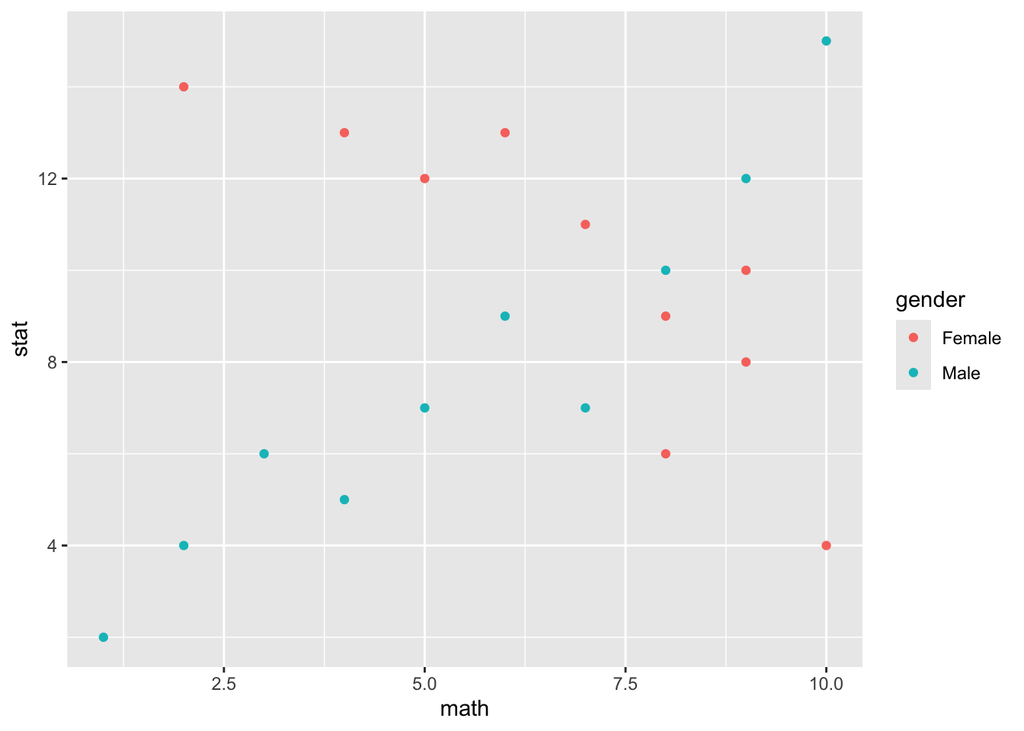

```r
ggplot(data = df1) +
  geom_point(mapping = aes(x = math,
   y = stat,
   color = gender))
```

- Both `data =` and `mapping =` are the first argument and they are omissible  
  → You can rewrite the R code above as follows:

```r
ggplot(df1) +
  geom_point(aes(x = math,
 y = stat,
 color = gender))
```

- Further, by using the pipe operator (`%>%` or `|>`), you can rewrite it as follows:
- You can use the pipe operator (`%>%` or `|>`) to link command together.
- This tell `R` to do something and then something else to the output of the first something.
- Chaining functions together like this will become very useful as your tasks become more complicated.

```r
df1 %>%
  ggplot() +
  geom_point(aes(x = math,
                 y = stat,
                 color = gender))
```

##### Mapping `aes()` and omission of R code

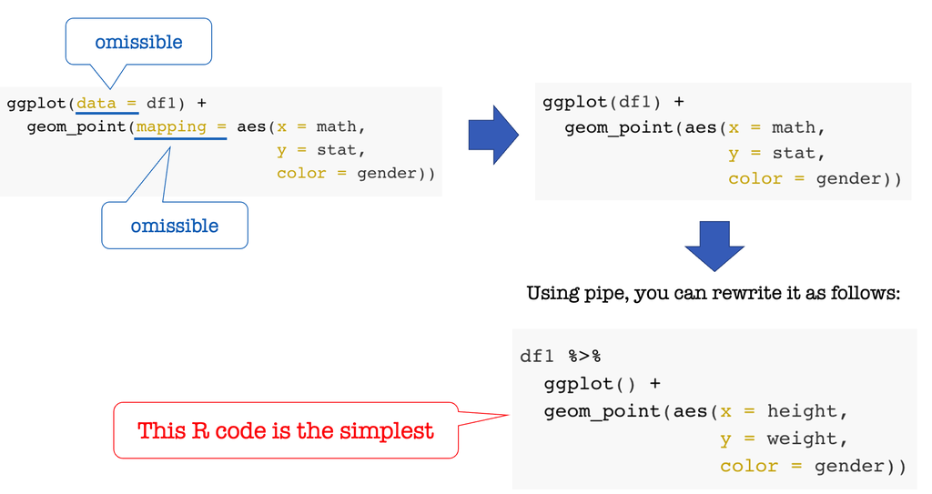

Summary on mapping `aes()` ・In `Step 2: Assign the variables`, `aes(x = math, y = stat)` is added by `+` after `ggplot(data = df1)`

```r
ggplot(data = df1) +
  aes(x = math, y = stat) +
  geom_point()
```

**`aes(x = math, y = stat)` can not only be added within `ggplot()`、but also be added within `geom_point()`**

- In sum, you have two ways of mapping `aes()`:

##### Mapping `aes()` within `ggplot()`

```r
df1 %>%
  ggplot(aes(x = math,
 y = stat,
 color = gender) +
  geom_point()
```

##### Mapping `aes()` within `geom_plot()`

```r
df1 %>%
  ggplot() +
  geom_point(aes(x = math,
 y = stat,
 color = gender))
```

- Which way you choose all depends on what you want to do in your analysis

How pipes (`%>%` or `|>`) are used ・The pipes (`%>%` or `|>`) allow you to express a sequence of multiple operations  
・`%>%` and `|>` can be used interchangeably.  
・Pipes can greatly simplify your code and make your operations more intuitive  
・The pipe operator (`%>%`) is automatically imported as part of the {`tidyverse`} library  
・Pipes (`%>%`) are included in {`magrittr`} package  
・{`magrittr`} package is included in `{tidyverse}` package  
→ You need to read either of the following packages to use the pipe operator (`%>%`)

```r
library(magrittr)
library(tidyverse)
```

**The pipe operator (`%>%`) automatically passes the output from the first line into the next line as the input**

- You can use the pipe operator (`%>%`) to link command together.
- This tell `R` to do something and then something else to the output of the first something.
- Chaining functions together like this will become very useful as your tasks become more complicated.

##### Let’s take a look at an exmple of using the pipe

- Generate vectors from 1 to 10

```r
1:10
```

```
 [1]  1  2  3  4  5  6  7  8  9 10
```

- Calculate `1 + 2 + .... + 10`

```r
sum(1:10)
```

```
[1] 55
```

- If you use pipe (`%>%`), you write R code as follows:

```r
1:10 %>%  # Generate vectors from 1 to 10
  sum()  # Add them all
```

```
[1] 55
```

- If you want to calculate the square root, …

```r
1:10 %>%# Generate vectors from 1 to 10
  sum() %>% # Add them all
  sqrt()   # Calculate the square root
```

```
[1] 7.416198
```

- Generate vectors from 1 to 10 → Add them all → Calculate the square root
- This is easier to interpret the sequence of operations

##### If you don’t use pipes,…

```r
sqrt(sum(1:10))
```

```
[1] 7.416198
```

- This is less intuitive because you have to think backward
- Calculate the square roof ← Add them all ← Generate vectors

How to interpret R code with pipes (`%>%`) ・You can interpret the R code you made in `4.1 A simple scatter plot` as follows:

```r
df1 %>%　　  　　 # Use df1 as data
  ggplot(aes(x = math,   # Assign x = math
 y = stat,   # Assign y = stat
 color = gender)) + # Dots are colored by gender
  geom_point()  # Draw a scatter plot
```

・`df1 %>% ggplot()` means the first argument of `ggplot`() is `df1` **Interpretation of the R code**:  
・Use `df1` as data  
→ Assign x = math  
→ Assign y = stat  
→ Dots are colored by gender  
→ Draw a scatter plot  
・You don’t have to go backward in interpreting the R code  
・R code with pipes (`%>%`) are intuitive and easy to follow

# 5. Customizing a graph (basic)

- Here, we are customizing a simple scatter plot we made above by assigning the following 9 most commonly used aesthetic elements:

[output not shown]

## 5.1 Dot color, shape, size, and background

- Let’s customize ①, ②, ③, and ④
- Note that since `size` and `shape` are applied for every point, you assign them out of `aes()`

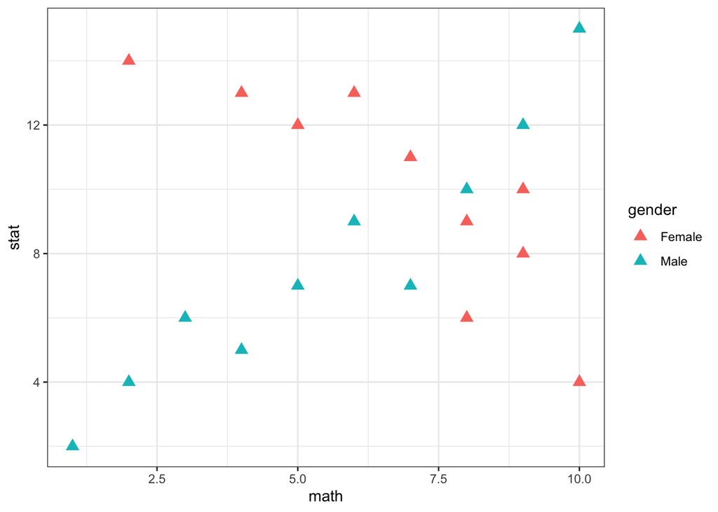

```r
df1 %>%
  ggplot() +
  geom_point(aes(x = math,
   y = stat,
   color = gender),
size = 3,
shape = 17) +
  theme_bw() # Change the backgroud color to black-and-white
```

- You can select dot `shape` from the following list:

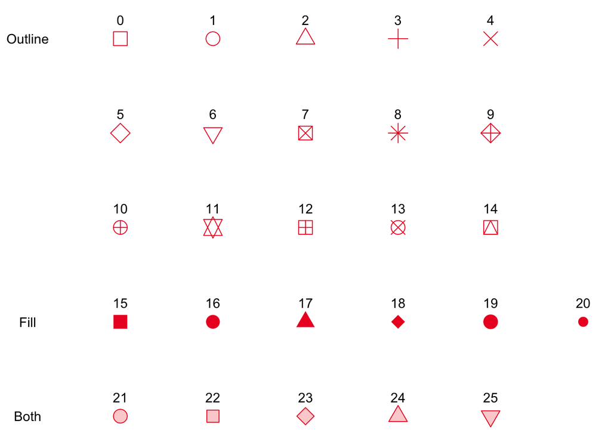

Depending on the location of argument of `aes()`, dot color changes

#### Dot color changes depending on the location of argument of `aes()`

| (1) `color` mapped within `aes()` | Dots are colored depending on the value of the variable |
| --- | --- |
| (2) color mapped **out of `aes()`** | : Applied to all dots |

##### (1) When `color = gender` is mapped within `aes()`

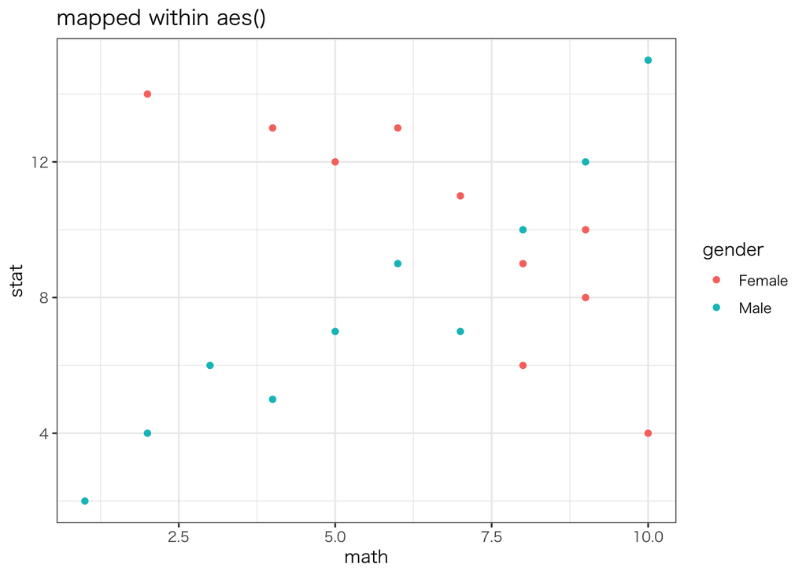

```r
plt_1 <- df1 %>%
  ggplot() +
  geom_point(aes(x = math,
   y = stat,
   color = gender)) + 　　# mapped within aes()
  ggtitle("mapped within aes()") +
  theme_bw(base_family = "HiraKakuProN-W3")
plt_1
```

##### (2) When `color = "magenta"` is mapped out of `aes()` : Applied to all dots

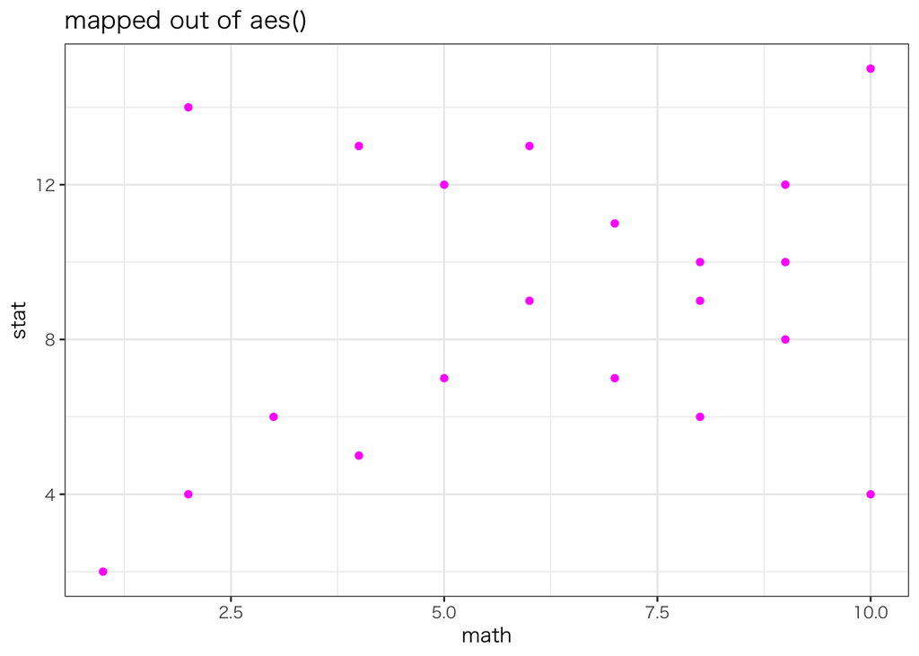

```r
plt_2  <- df1 %>%
  ggplot() +
  geom_point(aes(x = math,
   y = stat),
   color = "magenta") + 　　 # mapped out of aes()
  ggtitle("mapped out of aes()") +
  theme_bw(base_family = "HiraKakuProN-W3")
plt_2
```

```r
library(patchwork)
```

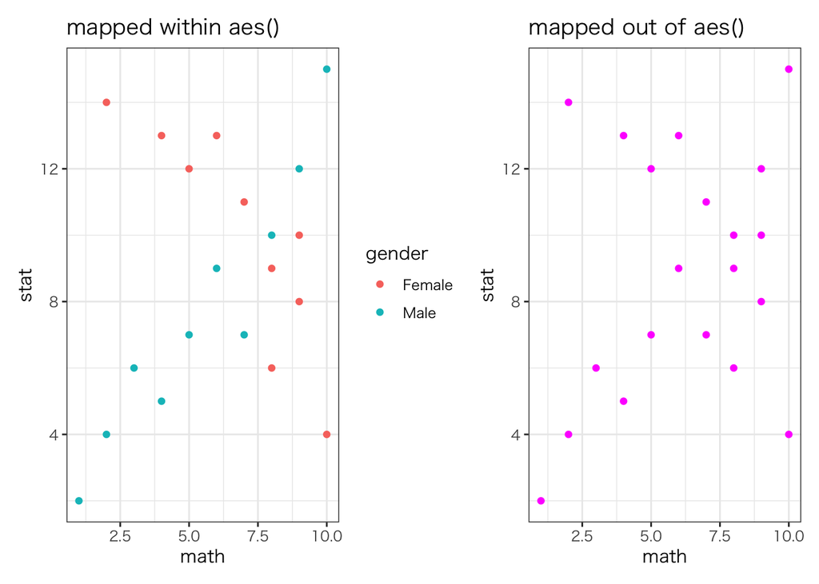

```r
plt_1 + plt_2
```

## 5.2 Label the axis

- Customize ⑤
- If you want to put a labe on `x-axis` and `y-axis`, you use `labs()`
- `labs(x = "...", y = "...")`

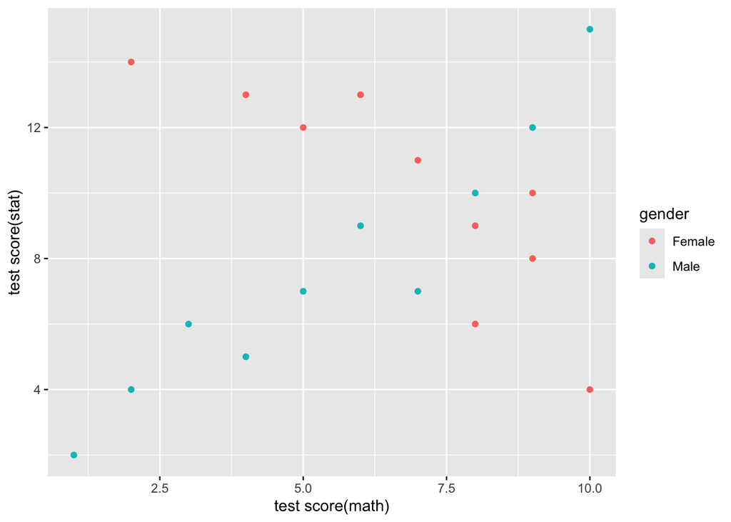

```r
df1 %>%
  ggplot() +
  geom_point(mapping = aes(x = math,
y = stat,
color = gender)) +
  labs(x = "test score(math)", y = "test score(stat)")
```

## 5.3 Main title

- Customize ⑥
- If you want to put main title, use `ggtitle("...")`

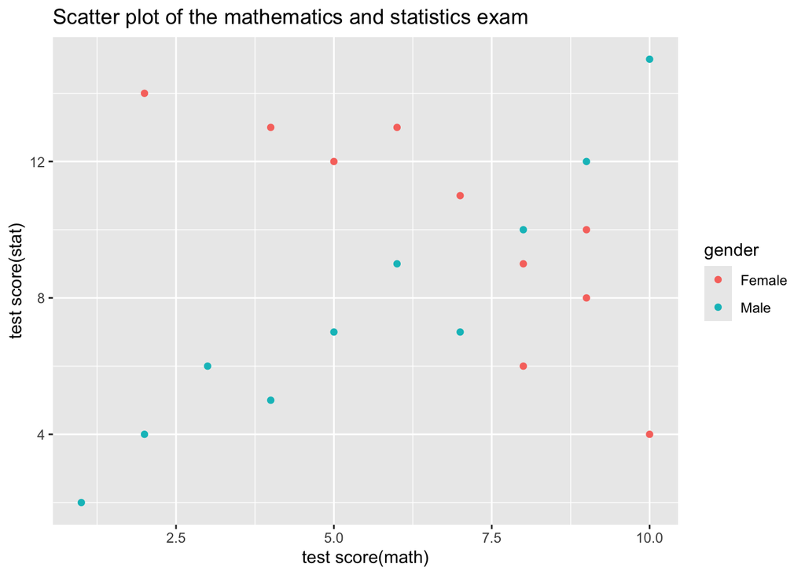

```r
df1 %>%
  ggplot() +
  geom_point(mapping = aes(x = math,# mapping = は省略可
y = stat,
color = gender)) +
  labs(x = "test score(math)", y = "test score(stat)") +
  ggtitle("Scatter plot of the mathematics and statistics exam")
```

## 5.4 Show Japanese in a graph

- Customize ⑦
- You can fix the garbled characters on `RMarkdown`, you should set the following:

##### How to fix the garbled characters on `RMarkdown`

| 1. In RStudio menu, **Tools** → **Global Options** → **Graphics** |
| --- |
| 2. Choose *AGG* in **Backend** → Click **Apply** |

[figure not shown]

#### Setting to use Japanese in a graph using `theme()`

- If you want to use Japanese in variable name or main title, you add the following R code after `+`
- `theme_bw(base_family = "HiraKakuProN-W3")`
- You can change the backgroud color to black and white by typing `theme_bw`
- You can also change the font size with `base_size = ...`

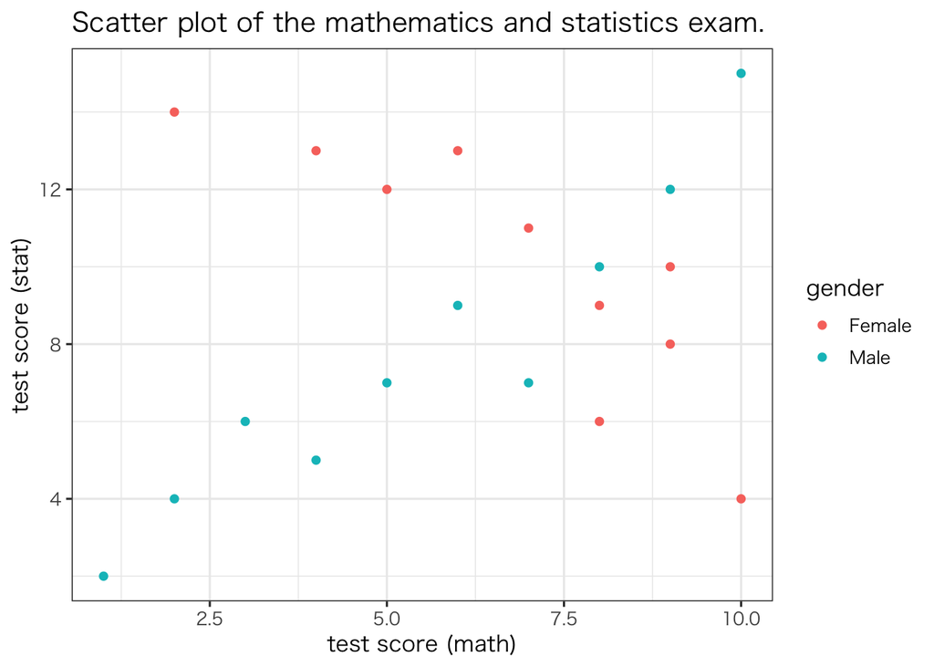

```r
df1 %>%
  ggplot() +
  geom_point(mapping = aes(x = math,# mapping = は省略可
y = stat,
color = gender)) +
  labs(x = "test score (math)", y = "test score (stat)") +
  ggtitle("Scatter plot of the mathematics and statistics exam.") +
  theme_bw(base_family = "HiraKakuProN-W3",
   base_size = 12)
```

2 ways of adding main title to a graph 1. `ggtitle(".....")`  
2. `labs(title = "....")`

・You get the same result if you use the following R code:

```r
df1 %>%
  ggplot() +
  geom_point(mapping = aes(x = math,# mapping = は省略可
y = stat,
color = gender)) +
  labs(x = "test score (math)",
  y = "test score (stat)",
  title = "Scatter plot of the mathematics and statistics exam.") +
  theme_bw(base_family = "HiraKakuProN-W3",
   base_size = 12)
```

## 5.5 Legend Location

- Customize ⑧
- You can customize the location of legend adding the following R code: `theme(legend.position ="")`
- You have the following 5 options:  
  ・`"none"`  
  ・`"top"`  
  ・`"left"`  
  ・`"right"`  
  ・`"bottom"`
- Here, lets put the legend at the bottom: `theme(legend.position = "bottom")`

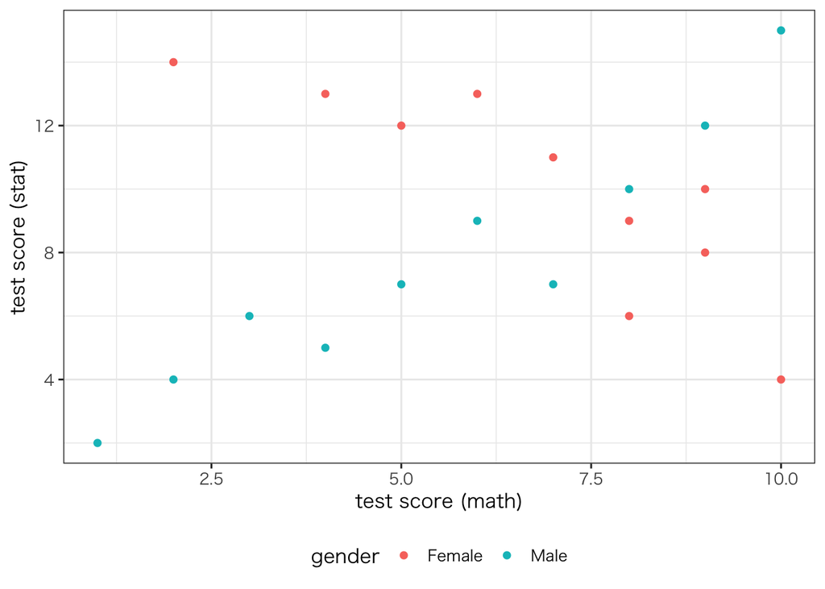

```r
df1 %>%
  ggplot() +
  geom_point(mapping = aes(x = math,
y = stat,
color = gender)) +
  labs(x = "test score (math)", y = "test score (stat)") +
  theme_bw(base_family = "HiraKakuProN-W3",
   base_size = 12) +
  theme(legend.position = "bottom") # put the legend at the bottom
```

- For details on the locatio of legend using `{ggplot2}`, see [this](https://blog.atusy.net/2018/11/10/ggplot2-legend-pos-n-just/)

## 5.6 Show a regression line

#### If you want to use the same color for dots and a line

- You need to map within `aes()`
- Add `geom_smooth(method = lm)`, then you draw a line for your `linear model`
- Add `geom_smooth()` following an operator `+`

```r
df1  %>%
  ggplot() +
  geom_point(aes(x = math,
   y = stat,
   color = gender)) +
  geom_smooth(method = lm) +　　　# Draw a regression line
  ggtitle("Scatter plot of the mathematics and statistics exam") +
  theme_bw(base_family = "HiraKakuProN-W3")
```

- In this case, you face the following error message:

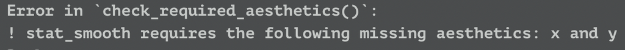

- This message says `x` and `y` are missing, so you cannot draw a regression line
- **Why this happen?**：Two aesthetic elements `(x` and `y`) are only linked WITHIN `geom_point()`
- **Solution**：You need to link two aesthetic elements `(x` and `y`) within `ggplot()` (which is a `higher layer` than `geom_point()`)

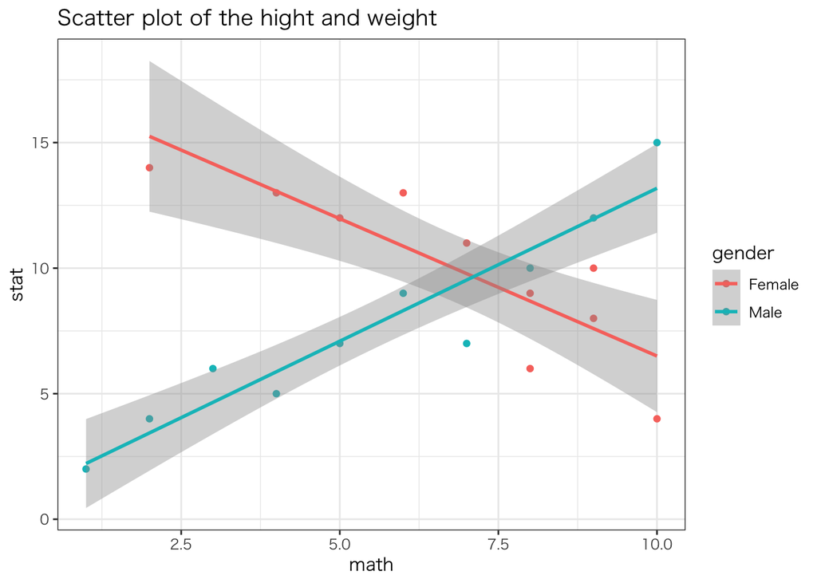

```r
df1  %>%
  ggplot(aes(x = math,   # Map x and y within ggplot()
y = stat,
color = gender)) +
  geom_point() +
  geom_smooth(method = lm) +
  ggtitle("Scatter plot of the hight and weight") +
  theme_bw(base_family = "HiraKakuProN-W3")
```

#### If you want to use the dots in different colors, but the color of the lines is the same

- Here, let’s draw lines in black

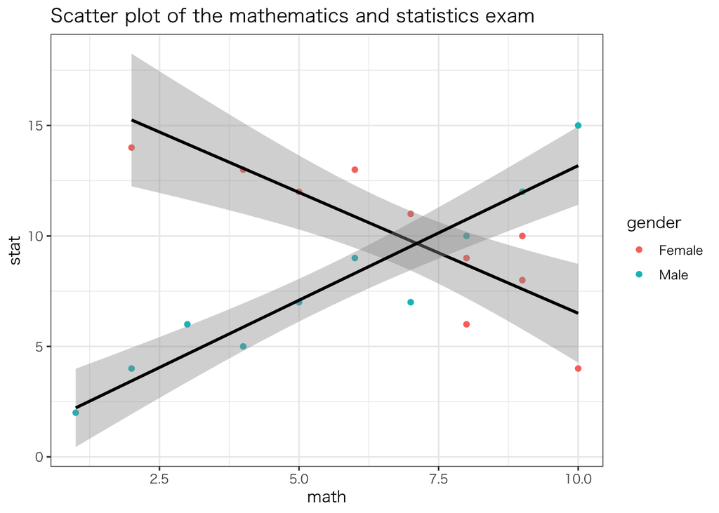

```r
df1  %>%
  ggplot(aes(x = math,   # ggplot() の内部で x と y を指定
y = stat)) +
  geom_point(aes(color = gender)) +
  geom_smooth(aes(group = gender),
method = lm,
color = "black") +
  ggtitle("Scatter plot of the mathematics and statistics exam") +
  theme_bw(base_family = "HiraKakuProN-W3")
```

Color variations available for `{ggplot2}` ・**As many as 657 colors** ara available for `{ggplot2}` you can use  
・You can choose and assign colors, like `"deeppink"`, `"skyblue"`, `"royalblue"` **OUT OF `aes()`**

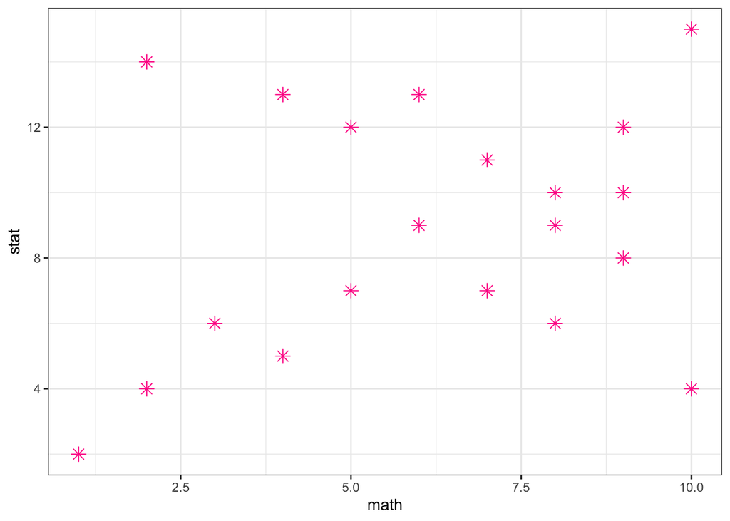

```r
df1 %>%
  ggplot() +
  geom_point(aes(x = math,
   y = stat),
size = 3,
color = "deeppink", # Assign colors out of aes()
shape = 8) +
  theme_bw()
```

・You can check how the name of the colors you can use for `{ggplot2}` by typing `colors()` in Console  
・Here, I will show you an example:

```r
head(colors())
```

```
[1] "white"         "aliceblue"     "antiquewhite"  "antiquewhite1"
[5] "antiquewhite2" "antiquewhite3"
```

・If you use `HEmath Code`, you can use as many as **16,777,216** colors!!!  
・For instance, if you assign red, you type `"#FF0000"`  
・The followings are a part of entire colors available in `HEmath Code`

[figure not shown]

Source:https://blog.albertkuo.me/post/point-shape-options-in-ggplot/

# 6. Customizing a graph (advance)

- Here I introduce how to customize a graph using 10 most commonly used layers

#### 10 most commonly used layers:

| **Elements** | **`{package}:function()`** | **What you can do** |
| --- | --- | --- |
| **1. Labels** | `labs*()` | Customize the labels on legend and axis |
| **2. Theme** | `theme_()`, `theme_*()` | Customize the outlook of a graph |
| **3. Coordinate System** | `coord_*()` | Customize the outlook of coordinate system |
| **4. Statistics** | `stat_*()` | Customize statistical stuff |
| **5. Scale** | `scale_*()_` | Customize glaph’s colors and shapes |
| **6. Identifying dots** | `{ggrepel}` | Identify what dots represent in scatter plot |
| **7. Hilight** | `{gghighlight}` | Emphasizing a particular data |
| **8. Facet** | `facet_*()` | Making multiple graphs |
| **9. Patchwork** | `{patchwork}` | Arranging multiple graphs |
| **10. Interactive graph** | `{plotly}` | Making an interactive graph |

#### Data preparation

```r
hr <- read_csv("data/hr96-26.csv", na = ".")
```

- `hr96_26.csv` is a collection of Japanese lower house election data covering 11 national elections (1996, 2000, 2003, 2005, 2009, 2012, 2014, 2017, 2021, 2024, and 2026）
- Check the name of variables `hr` contains

```r
names(hr)
```

```
 [1] "year"          "pref"          "ku"            "kun"
 [5] "rank"          "wl"            "nocand"        "seito"
 [9] "j_name"        "name"          "previous"      "gender"
[13] "age"           "exp"           "status"        "vote"
[17] "voteshare"     "eligible"      "turnout"       "seshu_dummy"
[21] "jiban_seshu"   "nojiban_seshu"
```

[output not shown]

##### 2 ways of checking the data downloaded:

##### (1) `DT::datatable()`

```r
DT::datatable(hr)
```

|  | year | pref | ku | kun | rank | wl | nocand | seito | j_name | name | previous | gender | age | exp | status | vote | voteshare | eligible | turnout | seshu_dummy | jiban_seshu | nojiban_seshu |
| --- | --- | --- | --- | --- | --- | --- | --- | --- | --- | --- | --- | --- | --- | --- | --- | --- | --- | --- | --- | --- | --- | --- |
| 1 | 1996 | 愛知 | aichi | 1 | 7 | 0 | 7 | 無所 | 浅野光雪 | ASANO, KOSETSU | 0 | male | 45 |  | 0 | 312 | 0.2 | 346774 | 49.2 | 0 |  |  |
| 2 | 1996 | 愛知 | aichi | 1 | 6 | 0 | 7 | 国民党 | 山田浩 | YAMADA, HIROSHI | 0 | male | 51 |  | 0 | 566 | 0.3 | 346774 | 49.2 | 0 |  |  |
| 3 | 1996 | 愛知 | aichi | 1 | 5 | 0 | 7 | 文化フォーラム | 伊東マサコ | ITO, MASAKO | 0 | female | 51 |  | 0 | 616 | 0.4 | 346774 | 49.2 | 0 |  |  |
| 4 | 1996 | 愛知 | aichi | 1 | 4 | 0 | 7 | 共産 | 岩中美保子 | IWANAKA, MIHOKO | 0 | female | 43 | 2177203 | 0 | 22209 | 13.3 | 346774 | 49.2 | 0 |  |  |
| 5 | 1996 | 愛知 | aichi | 1 | 3 | 0 | 7 | 民主 | 佐藤泰介 | SATO, TAISUKE | 1 | male | 53 | 9231284 | 1 | 33503 | 20.1 | 346774 | 49.2 | 0 |  |  |
| 6 | 1996 | 愛知 | aichi | 1 | 2 | 0 | 7 | 自民 | 今枝敬雄 | IMAEDA, NORIO | 3 | male | 72 | 9311555 | 2 | 42969 | 25.7 | 346774 | 49.2 | 0 |  |  |
| 7 | 1996 | 愛知 | aichi | 1 | 1 | 1 | 7 | 新進 | 河村たかし | KAWAMURA, TAKASHI | 1 | male | 47 | 9828097 | 1 | 66876 | 40 | 346774 | 49.2 | 0 |  |  |
| 8 | 1996 | 愛知 | aichi | 2 | 8 | 0 | 8 | 国民党 | 山崎義章 | YAMAZAKI, YOSHIAKI | 0 | male | 43 |  | 0 | 348 | 0.2 | 338310 | 51.8 | 0 |  |  |
| 9 | 1996 | 愛知 | aichi | 2 | 7 | 0 | 8 | 無所 | 村松陽一 | MURAMATSU, YOICHI | 0 | male | 47 |  | 0 | 418 | 0.2 | 338310 | 51.8 | 0 |  |  |
| 10 | 1996 | 愛知 | aichi | 2 | 6 | 0 | 8 | 文化フォーラム | 石川和己 | ISHIKAWA, KAZUMI | 0 | male | 61 |  | 0 | 701 | 0.4 | 338310 | 51.8 | 0 |  |  |

[output cut: 11882 more lines]

##### (2) `reactable:reactable()`

- Using `reactable:reactable()` enables us to search **with multiple conditions**

```r
reactable::reactable(hr,
  filterable = TRUE,    # Set you can search
  defaultPageSize = 10) # Set the maximum number of rows
```

| year | pref | ku | kun | rank | wl | nocand | seito | j_name | name | previous | gender | age | exp | status | vote | voteshare | eligible | turnout | seshu_dummy | jiban_seshu | nojiban_seshu |
| --- | --- | --- | --- | --- | --- | --- | --- | --- | --- | --- | --- | --- | --- | --- | --- | --- | --- | --- | --- | --- | --- |
| 1996 | 愛知 | aichi | 1 | 7 | 0 | 7 | 無所 | 浅野光雪 | ASANO, KOSETSU | 0 | male | 45 | NA | 0 | 312 | 0.2 | 346774 | 49.2 | 0 | NA | NA |
| 1996 | 愛知 | aichi | 1 | 6 | 0 | 7 | 国民党 | 山田浩 | YAMADA, HIROSHI | 0 | male | 51 | NA | 0 | 566 | 0.3 | 346774 | 49.2 | 0 | NA | NA |
| 1996 | 愛知 | aichi | 1 | 5 | 0 | 7 | 文化フォーラム | 伊東マサコ | ITO, MASAKO | 0 | female | 51 | NA | 0 | 616 | 0.4 | 346774 | 49.2 | 0 | NA | NA |
| 1996 | 愛知 | aichi | 1 | 4 | 0 | 7 | 共産 | 岩中美保子 | IWANAKA, MIHOKO | 0 | female | 43 | 2177203 | 0 | 22209 | 13.3 | 346774 | 49.2 | 0 | NA | NA |
| 1996 | 愛知 | aichi | 1 | 3 | 0 | 7 | 民主 | 佐藤泰介 | SATO, TAISUKE | 1 | male | 53 | 9231284 | 1 | 33503 | 20.1 | 346774 | 49.2 | 0 | NA | NA |
| 1996 | 愛知 | aichi | 1 | 2 | 0 | 7 | 自民 | 今枝敬雄 | IMAEDA, NORIO | 3 | male | 72 | 9311555 | 2 | 42969 | 25.7 | 346774 | 49.2 | 0 | NA | NA |
| 1996 | 愛知 | aichi | 1 | 1 | 1 | 7 | 新進 | 河村たかし | KAWAMURA, TAKASHI | 1 | male | 47 | 9828097 | 1 | 66876 | 40 | 346774 | 49.2 | 0 | NA | NA |
| 1996 | 愛知 | aichi | 2 | 8 | 0 | 8 | 国民党 | 山崎義章 | YAMAZAKI, YOSHIAKI | 0 | male | 43 | NA | 0 | 348 | 0.2 | 338310 | 51.8 | 0 | NA | NA |
| 1996 | 愛知 | aichi | 2 | 7 | 0 | 8 | 無所 | 村松陽一 | MURAMATSU, YOICHI | 0 | male | 47 | NA | 0 | 418 | 0.2 | 338310 | 51.8 | 0 | NA | NA |
| 1996 | 愛知 | aichi | 2 | 6 | 0 | 8 | 文化フォーラム | 石川和己 | ISHIKAWA, KAZUMI | 0 | male | 61 | NA | 0 | 701 | 0.4 | 338310 | 51.8 | 0 | NA | NA |

[output cut: 11882 more lines]

## 6.1 Labels

- You need to put an appropriate variable name
- It should be not too long and not too short
- It should be short enough to correctly deliver what it means to you and others
- You use `labs()` to put a variable name

| **Elements** | **`{package}:function()`** | **What you can do** |
| --- | --- | --- |
| **1. ラベル** | `labs*()` | Customize the labels on legend and axis |

- Let’s draw a scatter plot between `exp` and `voteshare` in the 2005 lower house election:
- Suppose you are interested in the difference between the two major political parties in Japan on this scatter plot: LDP
- LDP (Liberal Democratic Party): shown as 自民 in variable `seito`  
  ・ `x-axis`: `exp`・・・Election expenditure (yen) spent by each candidate  
  ・ `y-axis`: `voteshare`・・・Vote share (%)

##### The scatter plot without customizing labels

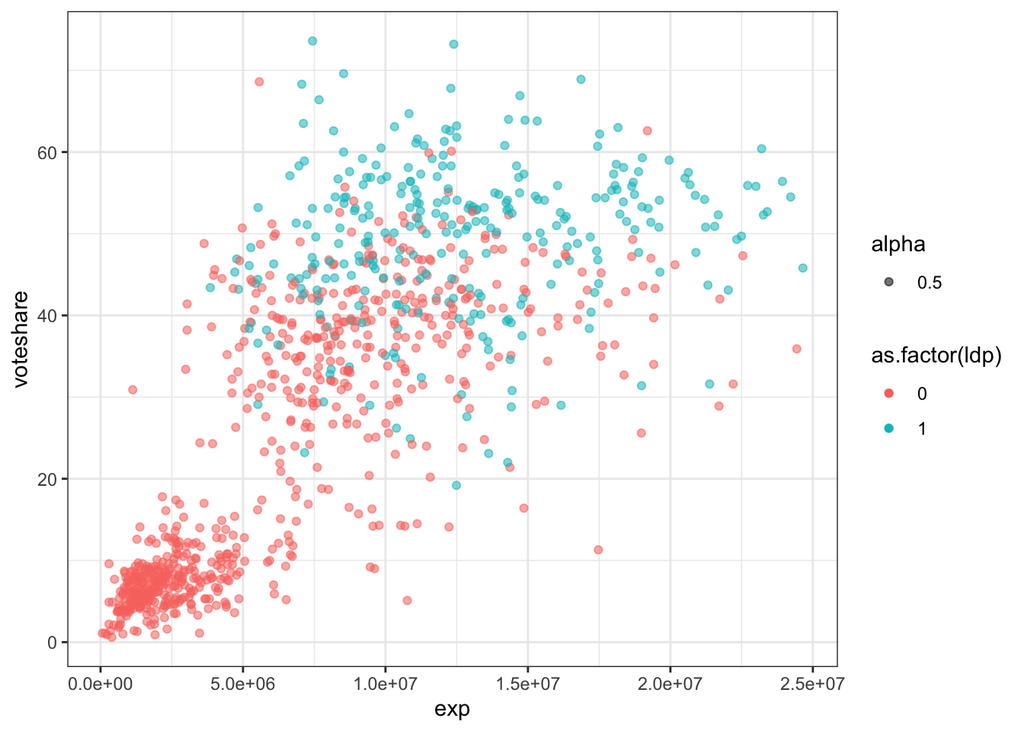

```r
hr %>%
  filter(year == 2005) %>% # Select 2005 election data only
  mutate(ldp = ifelse(seito == "自民", 1, 0)) %>% # Make a dummy variable for LDP: ldp = 1, 0 otherwise
  ggplot() +
  geom_point(aes(x = exp,
   y = voteshare,
   color = as.factor(ldp),
   alpha = 0.5)) +
  theme_bw()
```

##### The scatter plot with customizing labels

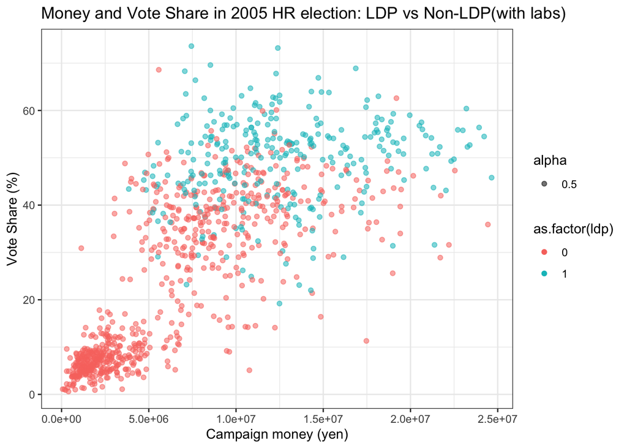

```r
hr %>%
  filter(year == 2005) %>%
  mutate(ldp = ifelse(seito == "自民", 1, 0)) %>%
  ggplot() +
  geom_point(aes(x = exp,
   y = voteshare,
   color = as.factor(ldp),
   alpha = 0.5)) +
  ggtitle("Money and Vote Share in 2005 HR election: LDP vs Non-LDP(with labs)") +
  theme_bw() +
  labs(x = "Campaign money (yen)",
  y = "Vote Share (%)")
```

## 6.2 Theme

| **Elements** | **`{package}:function()`** | **What you can do** |
| --- | --- | --- |
| **2. Theme** | `theme_()`, `theme_*()` | Customize the outlook of a graph |

- You can customize **the things which are nothing to do with a graph**, such as font, background color, and its style
- `theme_*()` has `base_family` argument  
  → You can assign the type of fonts applied to all elements in a graph
- If you want to use Japanese, you should add `theme_bw(base_family = "HiraKakuProN-W3"`

##### List of `theme_()`

| **Function** | **What you can do** |
| --- | --- |
| **`theme_grey()`** | Set the backgroud color as grey |
| **`theme_bw()`** | Set the backgroud color as white |
| **`theme_minimal()`** | Use the minimum items |
| **`theme_classic()`** | Set the classical style |

#### Without using `theme_()`

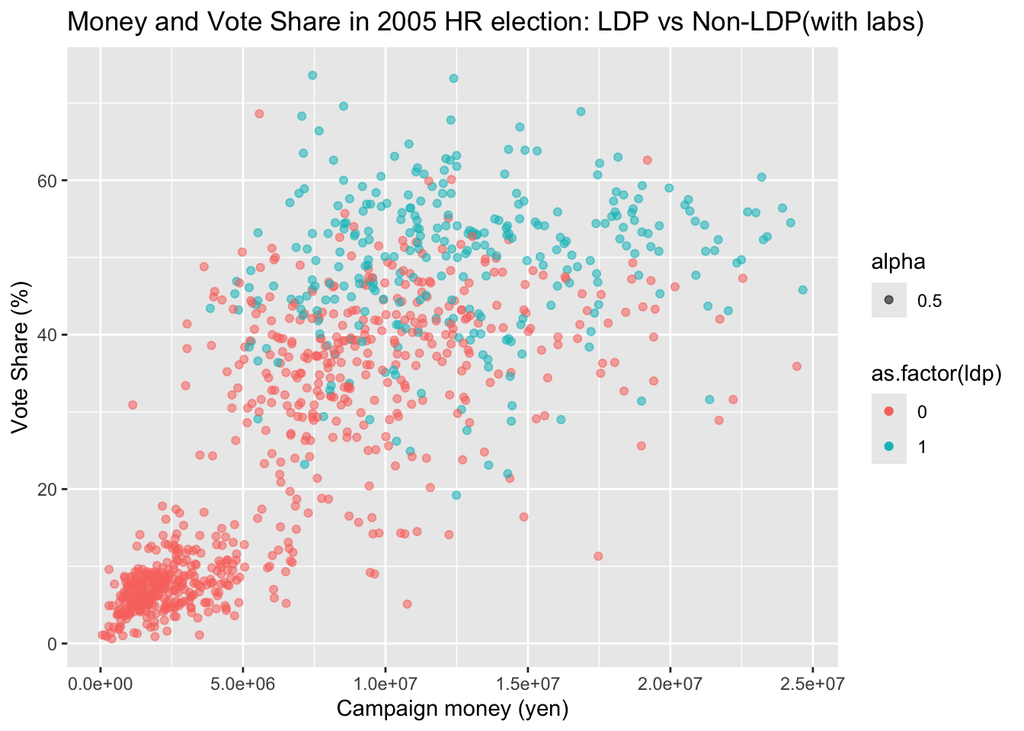

```r
plt_3 <- hr %>%
  filter(year == 2005) %>%
  mutate(ldp = ifelse(seito == "自民", 1, 0)) %>%
  ggplot() +
  geom_point(aes(x = exp,
   y = voteshare,
   color = as.factor(ldp),
   alpha = 0.5)) +
  ggtitle("Money and Vote Share in 2005 HR election: LDP vs Non-LDP(with labs)") +
  labs(x = "Campaign money (yen)",
  y = "Vote Share (%)")

plt_3
```

- You see the backgroud color is grey (grey is default)

#### If you want to use `theme_classic()`…..

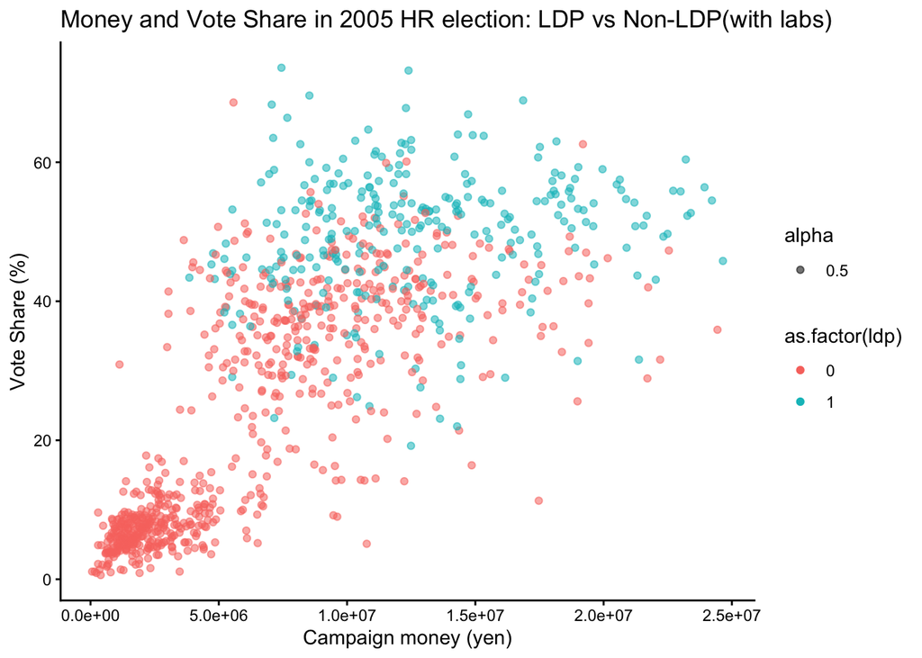

```r
plt_3 +
theme_classic()
```

#### List of `theme_*()` and their outlook

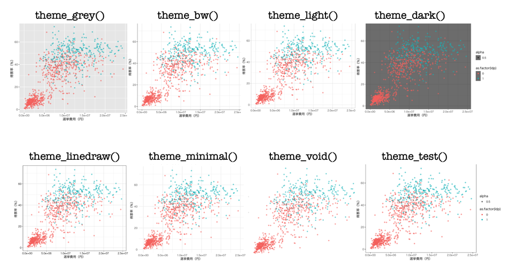

- You can choose whatever you like